# Inferring circulating COVID-19 cases from reported deaths

Thibaut Jombart, Sam Abbott, Amy Gimma, Christopher Jarvis, Timothy Russel, Sam Clifford, Sebastian Funk, Hamish Gibbs, Yang Liu, Kevin van Zandvoort, Rosalind Eggo, Adam Kurchaski, CMMID nCov working group, John Edmunds

Tuesday 24 March 2020

# 1 Data preparation

## 1.1 Outline

- **Load scripts**: loads libraries and useful scripts used in the analyses; all `.R` files contained in `scripts` at the root of the factory are automatically loaded
- **Load data**: imports datasets, and may contain some *ad hoc* changes to the data such as specific data cleaning (not used in other reports), new variables used in the analyses, etc.

## 1.2 Load packages

```r
library(here)
library(incidence)
library(distcrete)
library(epitrix)
library(tidyverse)
library(projections)

source("../../app/scripts/custom_graphics.R")
source("../../app/scripts/merge_add_projections.R")
source("../../app/scripts/merge_projections.R")
```

## 1.3 Load scripts

These scripts will load:

- all local scripts, stored as `.R` filesinside `/scripts/`
- all global scripts, i.e. stored outside the factory in `../scripts/`

# 2 Proof of concept

## 2.1 Model description

We aim to estimate the number of currently circulating cases on a given day given a number of deaths reported recently.

The principle of the estimation is:

1. for each death, draw a likely date of onset from the onset-to-death delay distribution; obtain one date of onset per death
2. allocate a batch of $n$ cases to each date of onset, where $n$ is drawn from a Binomial distribution with $p = CFR$; for each batch, simulate epi trajectories using a branching process (Poisson distribution)
3. add cases simulated from the different batches
4. repeat steps 1-3 a large number of times (`n_sim`), to reflect uncertainty on the actual dates of onsets
5. put all simulations together into a single `projections` object, and derive statistics from the simulations

## 2.2 Parameters of the model

This section contain information on the various parameters. We use these data to generate distribution, with discretisation when needed.

- **serial interval**: mean of 4.7 days, s.d. of 2.9 days (log normal distribution fit); source: https://www.medrxiv.org/content/10.1101/2020.02.03.20019497v2.full.pdf.
- **Onset-to-death distribution**: a Gamma(4.726, 0.3151). Source: https://www.mdpi.com/2077-0383/9/2/538
- **$R_0$**: somewhere between 1.6 - 4 depending on where the outbreak is and which paper you look at. Perhaps we should give a few different options for this as an input with a reasonable default value of 2.0? I only say this as it seems to be so context-specific. Source: https://wellcomeopenresearch.org/articles/5-17
- **CFR**: see that markdown file I sent to you for my estimates. Chris has some of his own. All estimates of this are a bit rubbish atm, but better ones are incoming (tomorrow!). For now something between 1-2% is pretty reasonable

## 2.3 Serial interval

`serial_interval` will be a `distcrete` object containing the serial interval distribution for a discretised log-normal with mean 4.7 and sd 2.9.

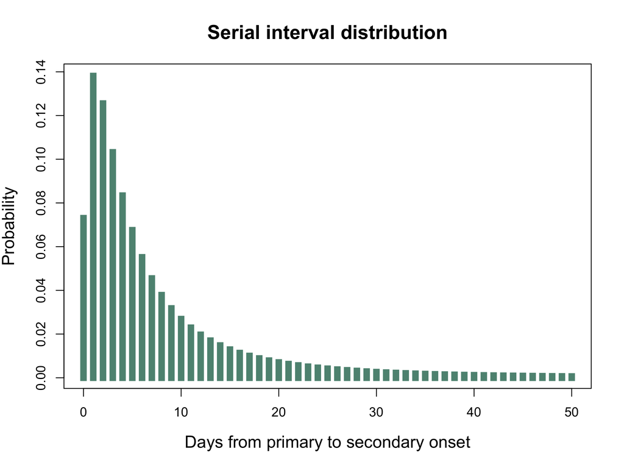

```r
## r_serial_interval() is a simulator for serial interval delays we use a
## log-normal with provided parameters, but cut the tail to ensure no values
## greater than 50 are simulated
serial_interval <- distcrete("lnorm", w = 0, interval = 1,
                             meanlog = log(4.7),
                             sdlog = log(2.9))

## example
plot(0:50, serial_interval$d(0:50),
     type = "h", col = "#5E9281", lwd = 8, lend = 2,
     xlab = "Days from primary to secondary onset",
     ylab = "Probability",
     main = "Serial interval distribution",
     cex.lab = 1.3, cex.main = 1.5)
```

## 2.4 Onset to death

`r_onset_death` will generate delays from onset to death using a discretised Gamma with parameters:

- shape: 4.726
- rate: 0.3151

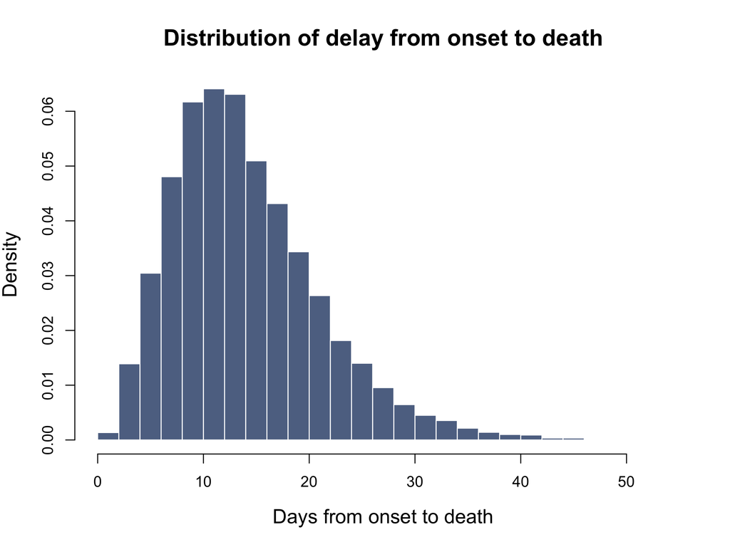

```r
r_onset_death <- function(n = 1, min_delay =1, max_delay = 60) {
  ## r_onset_death() will simulate delays from the above distribution, ensuring
  ## that simulated values do not exceed a given maximum;
  ## note: this is total overkill for now

  onset_death <- distcrete("gamma", w = 0, interval = 1,
                            shape = 4.726,
                           rate = 0.3151)

  out <- onset_death$r(n)
  to_replace <- (out < min_delay) | (out > max_delay)
  while (any(to_replace)) {
    out[to_replace] <- onset_death$r(sum(to_replace))
    to_replace <- out > max_delay
  }
  out
}



r_onset_death_alternative <- function(n = 1, min_delay = 1, max_delay = 60) {
  ## r_onset_death() will simulate delays from the above distribution, ensuring
  ## that simulated values do not exceed a given maximum;
  ## note: this is total overkill for now

  onset_death <- distcrete("lnorm", w = 0, interval = 1,
                           meanlog = 2.839078,
                           sdlog = 0.577242)

  out <- onset_death$r(n)
  to_replace <- (out < min_delay) | (out > max_delay)
  while (any(to_replace)) {
    out[to_replace] <- onset_death$r(sum(to_replace))
    to_replace <- out > max_delay
  }
  out
}


## example
hist(r_onset_death(10000),
     col = "#5E7192", border = "white", nclass = 30,
     xlab = "Days from onset to death",
     main = "Distribution of delay from onset to death",
     cex.lab = 1.3, cex.main = 1.5, prob = TRUE)
```

## 2.5 Cases per death

The number of cases associated to a given death is determined as the number of trials (cases) of a Binomial distribution with 1 “success” (deaths) and a probability of CFR. This is implemented using a Geometric distribution (discretised exponential).

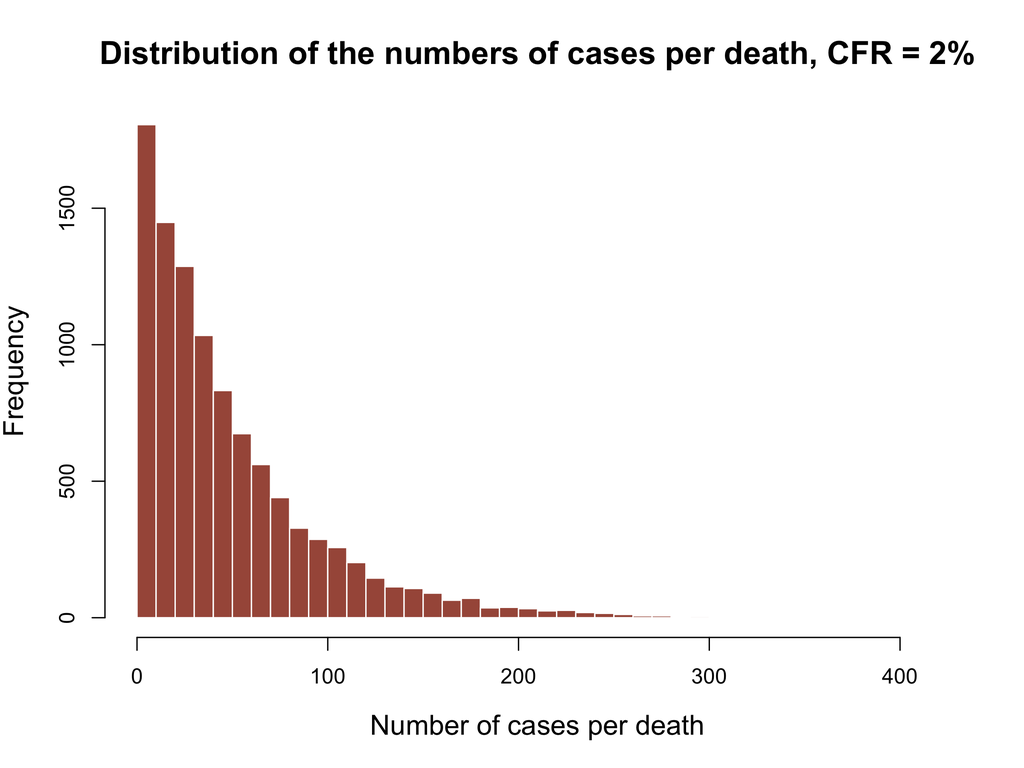

```r
hist(1+rgeom(n = 10000, prob = 0.02),
     col = "#A75848", border = "white", nclass = 30,
     xlab = "Number of cases per death",
     main = "Distribution of the numbers of cases per death, CFR = 2%",
     cex.lab = 1.3, cex.main = 1.5)
```

## 2.6 Illustration: a single death

As an illustration, we simulate a single death and apply the approach described above. We assume $R = 2$ and $CFR = 2%$.

```r
## get simulated dates of onset
cfr <- 0.02
n_cases_per_death <- 1+rgeom(1, prob = cfr)
date_death <- Sys.Date()
sim_onset <- rep(date_death - 14, n_cases_per_death)
head(sim_onset)
```

```
## [1] "2020-03-10" "2020-03-10" "2020-03-10" "2020-03-10" "2020-03-10"
## [6] "2020-03-10"
```

```r
## make incidence object

sim_i <- incidence(sim_onset)


## make case forecasting, assuming R = 2
## we simulate 1000 trajectories from a Poisson model

proj <- project(sim_i, R = 2, si = serial_interval, n_sim = 1000, n_days = 30)
stop_at <- max(date_death) + 7
to_keep <- get_dates(proj) <= stop_at
proj <- proj[to_keep, ]
proj
```

```
##
## /// Incidence projections //
##
##   // class: projections, matrix
##   // 21 dates (rows); 1,000 simulations (columns)
##
##  // first rows/columns:
##            [,1] [,2] [,3] [,4] [,5] [,6]
## 2020-03-11   20   27   18   15   11    9
## 2020-03-12   26   26   16   18   22   18
## 2020-03-13   19   25   19   20   18   16
## 2020-03-14   27   39   29   13   30   12
##  .
##  .
##  .
##
##  // dates:
##  [1] "2020-03-11" "2020-03-12" "2020-03-13" "2020-03-14" "2020-03-15"
##  [6] "2020-03-16" "2020-03-17" "2020-03-18" "2020-03-19" "2020-03-20"
## [11] "2020-03-21" "2020-03-22" "2020-03-23" "2020-03-24" "2020-03-25"
## [16] "2020-03-26" "2020-03-27" "2020-03-28" "2020-03-29" "2020-03-30"
## [21] "2020-03-31"
```

[figure not shown]

```r
plot(sim_i) %>%
  add_projections(proj) +
  theme_bw() +
  geom_vline(data = data.frame(death = date_death),
             aes(xintercept = death + 0.5),
             color = "#F13963", lwd = 1.5, alpha = .5) +
  scale_x_date(date_labels = "%d %b %Y") +
  labs(y = "Number of cases",
       title = "Epicurve simulated from CFR, by date of onset")
```

[figure not shown]

```r
plot(sim_i) %>%
  add_projections(cumulate(proj)) +
  theme_bw() +
  geom_vline(data = data.frame(death = date_death),
             aes(xintercept = death + 0.5),
             color = "#F13963", lwd = 1.5, alpha = .5) +
  scale_x_date(date_labels = "%d %b %Y") +
  labs(y = "Total number of cases",
       title = "Cumulative epicurve simulated from CFR, by date of onset")
```

## 2.7 Illustration: several deaths

We repeat the previous example but this time assuming three deaths a few days apart.

```r
## get simulated dates of onset
set.seed(1)
date_death <- Sys.Date() - c(0, 2, 7)
sim_onset <- lapply(date_death,
                    function(date) rep(date - 14, n_cases_per_death))
head(sim_onset)
## [[1]]
##  [1] "2020-03-10" "2020-03-10" "2020-03-10" "2020-03-10" "2020-03-10"
##  [6] "2020-03-10" "2020-03-10" "2020-03-10" "2020-03-10" "2020-03-10"
## [11] "2020-03-10" "2020-03-10" "2020-03-10" "2020-03-10" "2020-03-10"
## [16] "2020-03-10" "2020-03-10" "2020-03-10" "2020-03-10" "2020-03-10"
## [21] "2020-03-10" "2020-03-10" "2020-03-10" "2020-03-10" "2020-03-10"
## [26] "2020-03-10" "2020-03-10" "2020-03-10" "2020-03-10" "2020-03-10"
## [31] "2020-03-10" "2020-03-10" "2020-03-10" "2020-03-10" "2020-03-10"
## [36] "2020-03-10" "2020-03-10" "2020-03-10" "2020-03-10" "2020-03-10"
## [41] "2020-03-10" "2020-03-10" "2020-03-10" "2020-03-10" "2020-03-10"
## [46] "2020-03-10" "2020-03-10" "2020-03-10" "2020-03-10" "2020-03-10"
## [51] "2020-03-10" "2020-03-10" "2020-03-10" "2020-03-10" "2020-03-10"
## [56] "2020-03-10" "2020-03-10" "2020-03-10" "2020-03-10"
##
## [[2]]
##  [1] "2020-03-08" "2020-03-08" "2020-03-08" "2020-03-08" "2020-03-08"
##  [6] "2020-03-08" "2020-03-08" "2020-03-08" "2020-03-08" "2020-03-08"
## [11] "2020-03-08" "2020-03-08" "2020-03-08" "2020-03-08" "2020-03-08"
## [16] "2020-03-08" "2020-03-08" "2020-03-08" "2020-03-08" "2020-03-08"
## [21] "2020-03-08" "2020-03-08" "2020-03-08" "2020-03-08" "2020-03-08"
## [26] "2020-03-08" "2020-03-08" "2020-03-08" "2020-03-08" "2020-03-08"
## [31] "2020-03-08" "2020-03-08" "2020-03-08" "2020-03-08" "2020-03-08"
## [36] "2020-03-08" "2020-03-08" "2020-03-08" "2020-03-08" "2020-03-08"
## [41] "2020-03-08" "2020-03-08" "2020-03-08" "2020-03-08" "2020-03-08"
## [46] "2020-03-08" "2020-03-08" "2020-03-08" "2020-03-08" "2020-03-08"
## [51] "2020-03-08" "2020-03-08" "2020-03-08" "2020-03-08" "2020-03-08"
## [56] "2020-03-08" "2020-03-08" "2020-03-08" "2020-03-08"
##
## [[3]]
##  [1] "2020-03-03" "2020-03-03" "2020-03-03" "2020-03-03" "2020-03-03"
##  [6] "2020-03-03" "2020-03-03" "2020-03-03" "2020-03-03" "2020-03-03"
## [11] "2020-03-03" "2020-03-03" "2020-03-03" "2020-03-03" "2020-03-03"
## [16] "2020-03-03" "2020-03-03" "2020-03-03" "2020-03-03" "2020-03-03"
## [21] "2020-03-03" "2020-03-03" "2020-03-03" "2020-03-03" "2020-03-03"
## [26] "2020-03-03" "2020-03-03" "2020-03-03" "2020-03-03" "2020-03-03"
## [31] "2020-03-03" "2020-03-03" "2020-03-03" "2020-03-03" "2020-03-03"
## [36] "2020-03-03" "2020-03-03" "2020-03-03" "2020-03-03" "2020-03-03"
## [41] "2020-03-03" "2020-03-03" "2020-03-03" "2020-03-03" "2020-03-03"
## [46] "2020-03-03" "2020-03-03" "2020-03-03" "2020-03-03" "2020-03-03"
## [51] "2020-03-03" "2020-03-03" "2020-03-03" "2020-03-03" "2020-03-03"
## [56] "2020-03-03" "2020-03-03" "2020-03-03" "2020-03-03"



## make list of incidence objects
sim_i <- lapply(sim_onset, incidence)


## make case forecasting, assuming R = 2
## we simulate 1000 trajectories from a Poisson model

proj <- lapply(sim_i, project,
               R = 2, si = serial_interval,
               n_sim = 500, n_days = 30)

proj <- merge_add_projections(proj)

stop_at <- max(date_death) + 2
to_keep <- get_dates(proj) <= stop_at
proj <- proj[to_keep, ]
proj
```

```
##
## /// Incidence projections //
##
##   // class: projections, matrix
##   // 23 dates (rows); 500 simulations (columns)
##
##  // first rows/columns:
##            sim_1 sim_2 sim_3 sim_4 sim_5 sim_6
## 2020-03-04    10    15    19    17     9    11
## 2020-03-05    21    19    30    14    17    21
## 2020-03-06    23    24    21    17    16    13
## 2020-03-07    18    24    20    20    17    19
##  .
##  .
##  .
##
##  // dates:
##  [1] "2020-03-04" "2020-03-05" "2020-03-06" "2020-03-07" "2020-03-08"
##  [6] "2020-03-09" "2020-03-10" "2020-03-11" "2020-03-12" "2020-03-13"
## [11] "2020-03-14" "2020-03-15" "2020-03-16" "2020-03-17" "2020-03-18"
## [16] "2020-03-19" "2020-03-20" "2020-03-21" "2020-03-22" "2020-03-23"
## [21] "2020-03-24" "2020-03-25" "2020-03-26"
```

[figure not shown]

```r
Reduce(c, sim_onset) %>%
  incidence() %>%
  plot() %>%
  add_projections(proj) +
  theme_bw() +

  geom_vline(data = data.frame(death = date_death),
             aes(xintercept = death + 0.5),
             color = "#F13963", lwd = 1.5, alpha = .5) +
  scale_x_date(date_labels = "%d %b %Y") +

  labs(y = "Number of cases",
       title = "Epicurve simulated from CFR, by date of onset")
```

[figure not shown]

```r
Reduce(c, sim_onset) %>%
  incidence() %>%
  plot() %>%
  add_projections(cumulate(proj)) +
  theme_bw() +

  geom_vline(data = data.frame(death = date_death),
             aes(xintercept = death + 0.5),
             color = "#F13963", lwd = 1.5, alpha = .5) +
  scale_x_date(date_labels = "%d %b %Y") +

  labs(y = "Total number of cases",
       title = "Cumulative epicurve simulated from CFR, by date of onset")
```

# 3 Case simulator

## 3.1 Outline

Outputs will be a list including:

- `$date_death`: the date of death used as inputs
- `$incidence`: the epicurve simulated from the CFR, by date of onset
- `$projections`: the projections of cases

Additional inputs which will not be allowed to change would be stored using closures; they include:

- the serial interval distribution
- the onset to death distribution

```r
make_simulator <- function(serial_interval,
                           r_onset_death,
                           n_sim_per_iteration = 10) {

  function(date_death,
           R = 2,
           cfr = 0.02,
           n_sim = 100,
           duration = 1,
           infer_onset = TRUE) {

    ## TODO: add asserters and foolproofers here
    if (R < 1) {
      msg <- sprintf("invalid R requested (%d); setting `R = 1`",
                     R)
      message(msg)
      R <- 1
    }

    if (duration < 1) {
      msg <- sprintf("invalid duration requested (%d); setting `duration = 1`",
                     duration)
      message(msg)
      duration <- 1
    }

    if (n_sim < 10) {
      msg <- sprintf("n_sim requested too low (%d); setting `n_sim = 10`",
                     n_sim)
      message(msg)
      n_sim <- 10
    }

    if ((length(cfr) > 1) && (length(date_death) != length(cfr))) {
      msg <- "Several values of `cfr` provided but need 1 cfr per case"
      stop(msg)
    }

    ## Neutralise the onset -> death simulator if we have dates of onset already
    if (!infer_onset) {
      r_onset_death <- function(n = 1) rep(0, n)
    }


    ## Procedure:

    ## I) For each `nsim` simulation:

    ## 1. draw dates of onset for each deaths

    ## 2. build `incidence` objects for each death, containing 1/CFR cases for
    ## the respective onsets

    ## 3. make separate projections for each incidence objects, making sure
    ## simulation run until the day required

    ## 4. add projected cases from the different deaths into a single
    ## projection; this is now implemented by the external script
    ## `merge_add_projections`, soon to be part of the projections package

    ## II) merge projections from all iterations into a single projection object
    ## collate all forecastings together; ; this is now implemented by the
    ## external script `merge_projections`, soon to be part of the projections
    ## package

    last_day_simul <- max(date_death) + duration

    ## step I
    ## `proj` will contain forecasting output in a list of data.frame
    ## `all_sim_onset` will contain all simulated onsets
    proj <- vector(n_sim, mode = "list")
    all_sim_onset <- vector(n_sim, mode = "list")
    all_sim_n_cases <- vector(n_sim, mode = "list")

    for (i in seq_len(n_sim)) {

      ## step 1

      ## infer number of cases based on CFR
      n_death <- length(date_death)


      ## infer corresponding dates of onset, probabilistically; in a given
      ## iteration of the for loop, all dates of onset are the same for a given
      ## death; we keep these data in a list with one item per death, which
      ## allows the creation of separate incidence objects and separate
      ## projections for each death
      ##
      all_sim_onset[[i]] <- date_death - r_onset_death(n_death)
      all_sim_n_cases[[i]] <- 1 + rgeom(n = n_death, prob = cfr)

      sim_onset <- lapply(seq_len(n_death),
                          function(j) rep(all_sim_onset[[i]][j],
                                          all_sim_n_cases[[i]][j]))


      ## step 2
      ## make incidence object from simulated onsets
      sim_i <- lapply(sim_onset, incidence)


      ## step 3
      list_proj <- lapply(sim_i,
                          function(e)
                            project(e,
                                    R = R,
                                    si = serial_interval,
                                    n_sim = n_sim_per_iteration,
                                    n_days = as.integer(last_day_simul - max(get_dates(e)))))

      ## step 4
      proj[[i]] <- merge_add_projections(list_proj)

    } # end of for loop


    ## step 5
    proj <- merge_projections(proj)


    ## reshape `all_sim_onset` into a single vector of dates
    all_sim_onset <- Reduce(c, all_sim_onset)

    ## reshape `all_sim_n_cases` into a vector
    all_sim_n_cases <- unlist(all_sim_n_cases)

    ## make plot for output
    out_plot <-
      plot(proj, quantiles = FALSE,
           ribbon_alpha = .5,
           ribbon_quantiles = c(0.025, .975)) %>%
      add_projections(proj,
                      quantiles = FALSE,
                      ribbon_alpha = .75,
                      ribbon_quantiles = c(0.25, .75)) +
      theme_bw() +
      geom_vline(data = data.frame(death = date_death),
                 aes(xintercept = death),
                 color = "#F13963", lwd = 1.5, alpha = .5) +
      scale_x_date(date_label = "%d %b %y") +
      labs(y = "New daily cases",
           title = "Cases inferred from deaths: projections")


    ## make plot for output
    out_plot_cumul <-
      plot(cumulate(proj),
           quantiles = FALSE,
           ribbon_alpha = .5,
           ribbon_quantiles = c(0.025, .975)) %>%
      add_projections(cumulate(proj),
                      quantiles = FALSE,
                      ribbon_alpha = .75,
                      ribbon_quantiles = c(0.25, .75)) +
      theme_bw() +
      geom_vline(data = data.frame(death = date_death),
                 aes(xintercept = death),
                 color = "#F13963", lwd = 1.5, alpha = .5) +
      scale_x_date(date_label = "%d %b %y") +
      labs(y = "Total number of cases",
           title = "Cases inferred from deaths: cumulative projections")


    ## return output
    out <- list(
        date_death = date_death,
        sim_onset = all_sim_onset,
        sim_n_cases = all_sim_n_cases,
        projections = proj,
        plot_projections = out_plot,
        plot_projections_cumul = out_plot_cumul
    )

    out
  }
}


## default simulator
simulate_cases <- make_simulator(serial_interval,
                                 r_onset_death,
                                 50)


## alternative simulator, using right-censored distribution for the onset->death
## delay; this one creates longer delays and will tend to over-estimate cases
simulate_cases_alternative <- make_simulator(serial_interval,
                                             r_onset_death_alternative,
                                             50)
```

## 3.2 Basic example

An example using default parameters, with a new cases today:

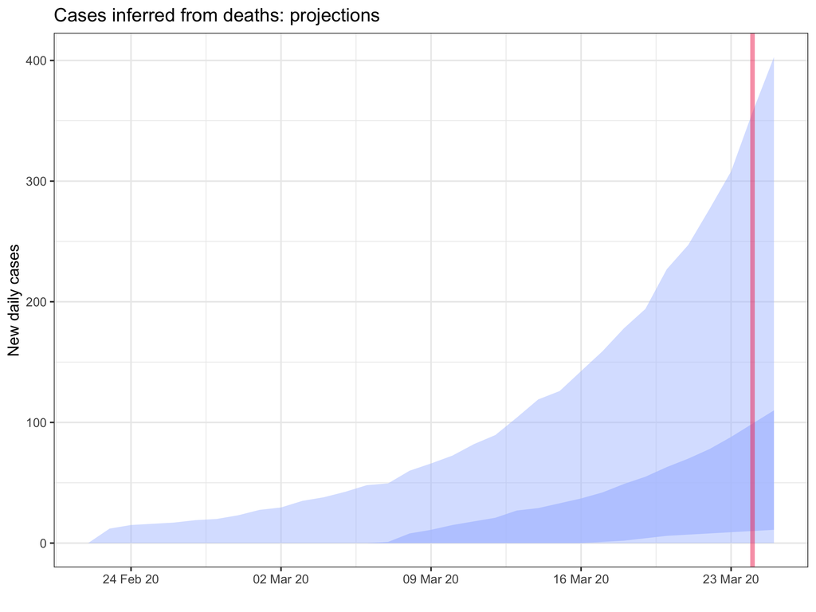

```r
set.seed(1)
today <- Sys.Date()
x <- simulate_cases(today, n_sim = 50)
x$plot_projections
```

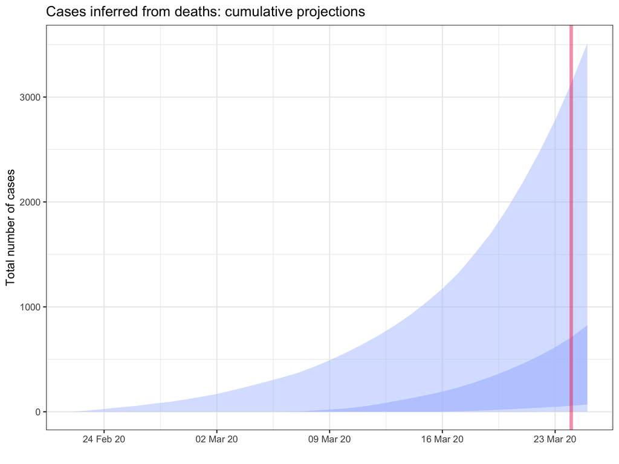

```r
x$plot_projections_cumul
```

## 3.3 More cases

Another example with 5 cases over the last week:

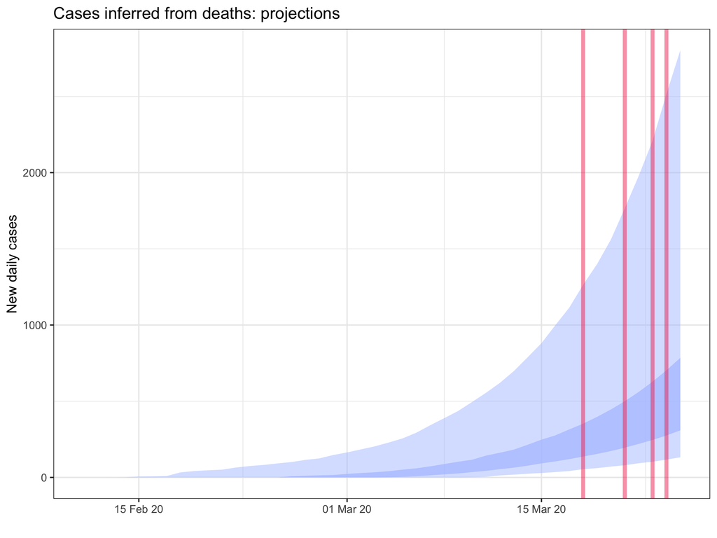

```r
set.seed(1)
today <- Sys.Date()
sim_death <- today - sample(0:6, 5, replace = TRUE)
x <- simulate_cases(sim_death, R = 2, cfr = 0.02)
x$plot_projections
```

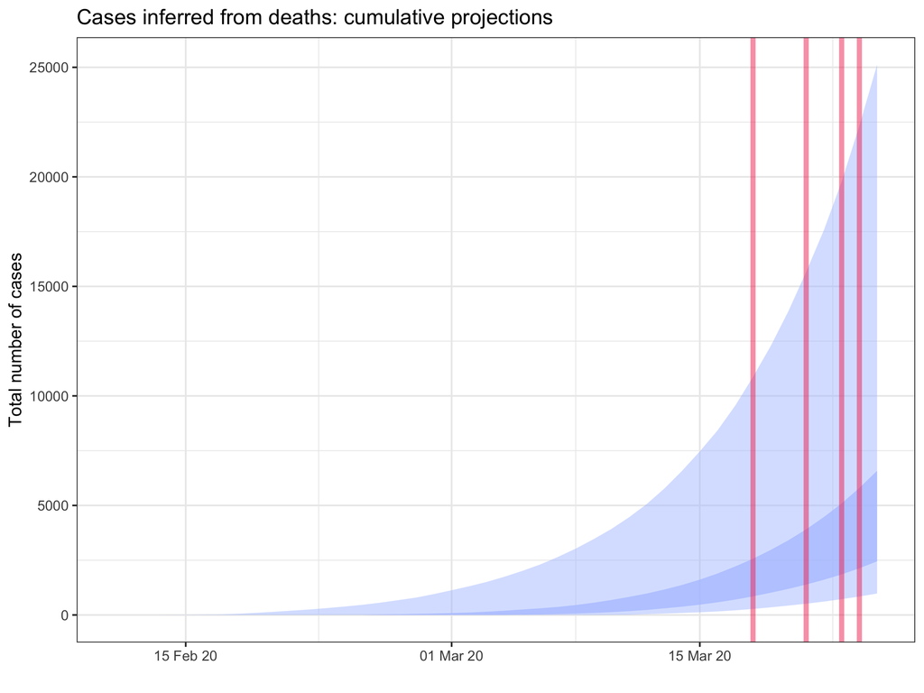

```r
x$plot_projections_cumul
```

# 4 Export

## 4.1 Simulator

The simulator is exported as an `rds` file. Because it uses closure programming, it should be functional out-of-the box, without having to re-specify the delay distributions.

```r
if (!dir.exists("rds_outputs")) {
  dir.create("rds_outputs")
}

## export to local folder
rio::export(simulate_cases,
            file = "rds_outputs/simulate_cases.rds")
rio::export(simulate_cases_alternative,
            file = "rds_outputs/simulate_cases_alternative.rds")

## export to main rds folder
rio::export(simulate_cases,
            file = here("rds", "simulate_cases.rds"))
rio::export(simulate_cases_alternative,
            file = here("rds", "simulate_cases_alternative.rds"))

## export to the app's folder
rio::export(simulate_cases,
            file = here("..", "app", "rds", "simulate_cases.rds"))
rio::export(simulate_cases_alternative,
            file = here("..", "app", "rds", "simulate_cases_alternative.rds"))
```

# 5 System information

## 5.1 Outline

The following information documents the system on which the document was compiled.

## 5.2 System

This provides information on the operating system.

```r
Sys.info()
```

```
##                                                                                            sysname
##                                                                                           "Darwin"
##                                                                                            release
##                                                                                           "18.6.0"
##                                                                                            version
## "Darwin Kernel Version 18.6.0: Thu Apr 25 23:16:27 PDT 2019; root:xnu-4903.261.4~2/RELEASE_X86_64"
##                                                                                           nodename
##                                                                         "MacBook-de-Rogerio.local"
##                                                                                            machine
##                                                                                           "x86_64"
##                                                                                              login
##                                                                                          "rchaves"
##                                                                                               user
##                                                                                          "rchaves"
##                                                                                     effective_user
##                                                                                          "rchaves"
```

## 5.3 R environment

This provides information on the version of R used:

```r
R.version
```

```
##                _
## platform       x86_64-apple-darwin15.6.0
## arch           x86_64
## os             darwin15.6.0
## system         x86_64, darwin15.6.0
## status
## major          3
## minor          6.3
## year           2020
## month          02
## day            29
## svn rev        77875
## language       R
## version.string R version 3.6.3 (2020-02-29)
## nickname       Holding the Windsock
```